# Máster en Data Science - Machine Learning

# Exploratory Data Analysis

##### Autor: Rodrigo Fernandez Campos

## DataSet: Bank Account Fraud Dataset Suite (NeurIPS 2022)

# **Encoding, Scaling y conclusión del EDA**

```python
# Librerías
import pandas as pd
import numpy as np
import matplotlib.pyplot as plt
import seaborn as sns
from termcolor import colored, cprint
import category_encoders as ce
from sklearn.preprocessing import OneHotEncoder
from sklearn.preprocessing import OrdinalEncoder
from sklearn.preprocessing import StandardScaler
import warnings
import sys

pd.set_option('display.max_columns', 500)
pd.set_option('display.max_rows', 500)
```

## Funciones

```python
sys.path.append('../functions/')
import functions_rfc as fr
sys.path.remove('../functions/')
```

## Importación del preprocesamiento anterior

```python
df_fraud_train = pd.read_csv('../data/interim/df_fraud_train.csv')
df_fraud_test = pd.read_csv('../data/interim/df_fraud_test.csv')
df_fraud_train.head()
```

|  | Unnamed: 0 | income | name_email_similarity | prev_address_months_count | current_address_months_count | customer_age | days_since_request | intended_balcon_amount | payment_type | zip_count_4w | velocity_6h | velocity_24h | velocity_4w | bank_branch_count_8w | date_of_birth_distinct_emails_4w | employment_status | credit_risk_score | email_is_free | housing_status | phone_home_valid | phone_mobile_valid | bank_months_count | has_other_cards | proposed_credit_limit | foreign_request | source | session_length_in_minutes | device_os | keep_alive_session | … |
| --- | --- | --- | --- | --- | --- | --- | --- | --- | --- | --- | --- | --- | --- | --- | --- | --- | --- | --- | --- | --- | --- | --- | --- | --- | --- | --- | --- | --- | --- | --- |
| 0 | 593143 | 0.8 | 0.433984 | 54 | 9 | 30 | 0.020608 | 49.172739 | AA | 954 | 5137.541683 | 2712.051960 | 4240.496920 | 2 | 11 | CA | 286 | 0 | BA | 0 | 1 | 1 | 1 | 1000.0 | 0 | INTERNET | 14.396148 | other | 0 | … |
| 1 | 566593 | 0.1 | 0.712826 | -1 | 97 | 50 | 0.024353 | -1.091855 | AB | 1108 | 4370.169334 | 3097.535634 | 4383.873312 | 0 | 6 | CA | 132 | 0 | BB | 1 | 1 | 28 | 1 | 200.0 | 0 | INTERNET | 4.100053 | other | 0 | … |
| 2 | 824376 | 0.4 | 0.222290 | 32 | 115 | 30 | 0.002837 | -1.067640 | AC | 266 | 7168.731474 | 2865.219877 | 4207.649556 | 0 | 11 | CA | 171 | 0 | BE | 0 | 1 | -1 | 1 | 200.0 | 0 | INTERNET | 2.369306 | other | 0 | … |
| 3 | 426074 | 0.7 | 0.476667 | -1 | 375 | 40 | 0.020157 | -0.930885 | AC | 962 | 4761.030105 | 6249.502233 | 6013.337906 | 0 | 8 | CA | 245 | 1 | BA | 0 | 1 | -1 | 1 | 1500.0 | 1 | INTERNET | 31.700024 | linux | 1 | … |
| 4 | 305196 | 0.1 | 0.506995 | 11 | 10 | 20 | 0.007662 | -0.698526 | AC | 874 | 8823.184279 | 6315.937497 | 5653.839202 | 0 | 13 | CD | 20 | 0 | BC | 0 | 1 | -1 | 0 | 200.0 | 0 | INTERNET | 0.592456 | linux | 1 | … |

```python
df_fraud_train.info()
```

```
<class 'pandas.core.frame.DataFrame'>
RangeIndex: 700000 entries, 0 to 699999
Data columns (total 32 columns):
 #   Column                            Non-Null Count   Dtype
---  ------                            --------------   -----
 0   Unnamed: 0                        700000 non-null  int64
 1   income                            700000 non-null  float64
 2   name_email_similarity             700000 non-null  float64
 3   prev_address_months_count         700000 non-null  int64
 4   current_address_months_count      700000 non-null  int64
 5   customer_age                      700000 non-null  int64
 6   days_since_request                700000 non-null  float64
 7   intended_balcon_amount            700000 non-null  float64
 8   payment_type                      700000 non-null  object
 9   zip_count_4w                      700000 non-null  int64
```

[output cut: 24 more lines]

```python
# Elimino la primera columna que repite el Index
df_fraud_train = df_fraud_train.drop('Unnamed: 0',axis=1)
df_fraud_test = df_fraud_test.drop('Unnamed: 0',axis=1)
```

```python
# Descripción de los datos:
var_description = pd.read_excel('../data/interim/variables_description.xlsx')
var_description
```

|  | Variable | Type | Description | Possible Values / Range | Missings |
| --- | --- | --- | --- | --- | --- |
| 0 | fraud_bool | binary | TARGET - If the application is fraudulent or not. | [1 0] | NaN |
| 1 | income | numeric | Annual income of the applicant (in decile form). | [0.1 to 0.9] | NaN |
| 2 | name_email_similarity | numeric | Metric of similarity between email and applic... | [0.00 to 1.00] | NaN |
| 3 | prev_address_months_count | numeric | Number of months in previous registered addre... | [-1.00 to 383.00] | -1 |
| 4 | current_address_months_count | numeric | Months in currently registered address of the... | [-1.00 to 429.00] | -1 |
| 5 | customer_age | numeric | Applicant’s age in years, rounded to the decade. | [10 20 30 40 50 60 70 80 90] | NaN |
| 6 | days_since_request | numeric | Number of days passed since application was d... | [0.00 to 79] | NaN |
| 7 | intended_balcon_amount | numeric | Initial transferred amount for application. | [-16 to 114] | Negatives |
| 8 | payment_type | categorical | Credit payment plan type. 5 possible (annonym... | ['AA' 'AB' 'AC' 'AD' 'AE'] | NaN |
| 9 | zip_count_4w | numeric | Number of applications within same zip code i... | [1.00 to 6700.00] | NaN |
| 10 | velocity_6h | numeric | Velocity of total applications made in last 6... | [-175 to 16818] | NaN |
| 11 | velocity_24h | numeric | Velocity of total applications made in last 2... | [1297 to 9586] | NaN |
| 12 | velocity_4w | numeric | Velocity of total applications made in last 4... | [2825.75 to 7020] | NaN |
| 13 | bank_branch_count_8w | numeric | Number of total applications in the selected ... | [0 to 2404] | NaN |
| 14 | date_of_birth_distinct_emails_4w | numeric | Number of emails for applicants with same dat... | [0 to 39] | NaN |
| 15 | employment_status | categorical | Employment status of the applicant. 7 possibl... | ['CA' 'CB' 'CC' 'CD' 'CE' 'CF' 'CG'] | NaN |
| 16 | credit_risk_score | numeric | Internal score of application risk. | [-191.00 to 389.00] | NaN |
| 17 | email_is_free | binary | Domain of application email (either free or p... | [0 1] | NaN |
| 18 | housing_status | categorical | Current residential status for applicant. 7 p... | ['BA' 'BB' 'BC' 'BD' 'BE' 'BF' 'BG'] | NaN |
| 19 | phone_home_valid | binary | Validity of provided home phone. | [1 0] | NaN |
| 20 | phone_mobile_valid | binary | Validity of provided mobile phone. | [0 1] | NaN |
| 21 | bank_months_count | numeric | How old is previous account (if held) in months. | [-1 to 32] | -1 |
| 22 | has_other_cards | binary | If applicant has other cards from the same ba... | [0 1] | NaN |
| 23 | proposed_credit_limit | numeric | Applicant’s proposed credit limit. | [200 to 2100] | NaN |
| 24 | foreign_request | binary | If origin country of request is different fro... | [0 1] | NaN |
| 25 | source | categorical | Online source of application. Either browser ... | ['INTERNET' 'TELEAPP'] | NaN |
| 26 | session_length_in_minutes | numeric | Length of user session in banking website in ... | [-1.00 to 107] | -1 |
| 27 | device_os | categorical | Operative system of device that made request ... | ['windows' 'other' 'linux' 'macintosh' 'x11'] | NaN |
| 28 | keep_alive_session | binary | User option on session logout. | [0 1] | NaN |
| 29 | device_distinct_emails_8w | numeric | Number of distinct emails in banking website ... | [ 1 2 0 -1] | -1 |
| 30 | device_fraud_count | numeric | Number of fraudulent applications with used d... | [0 1] | NaN |
| 31 | month | numeric | Month where the application was made. | [0 1 2 3 4 5 6 7] | NaN |

## Cambio de tipo a variables categoricas

Cambio el tipo de las variables categóricas de texto a 'category'

```python
# vuelvo a generar mis listas por tipos de variables
df_fraud_bool, df_fraud_cat, df_fraud_num = fr.tipos_vars(df_fraud_train,False)
```

```python
# Listado de variables categóricas String: Las variables a codificar
df_fraud_cat_string = list(df_fraud_train[df_fraud_cat].select_dtypes('object').columns.values)
df_fraud_cat_string
```

```
['payment_type', 'employment_status', 'housing_status', 'source', 'device_os']
```

```python
# Visualizo los detalles de todas las variables categóricas a codificar
fr.dame_info(df_fraud_cat_string, df_fraud_train, var_description)
```

```
 1. payment_type  :  Credit payment plan type. 5 possible (annonymized) values.
- Nulls: 0
- Values: ['AA' 'AB' 'AC' 'AD' 'AE']

 2. employment_status  :  Employment status of the applicant. 7 possible (annonymized) values.
- Nulls: 0
- Values: ['CA' 'CD' 'CE' 'CB' 'CC' 'CF' 'CG']

 3. housing_status  :  Current residential status for applicant. 7 possible (annonymized) values.
- Nulls: 0
- Values: ['BA' 'BB' 'BE' 'BC' 'BD' 'BF' 'BG']

 4. source  :  Online source of application. Either browser (INTERNET) or app (TELEAPP).
- Nulls: 0
- Values: ['INTERNET' 'TELEAPP']

 5. device_os  :  Operative system of device that made request (Windows, macOS, Linux, X11, or other).
- Nulls: 0
- Values: ['other' 'linux' 'windows' 'macintosh' 'x11']
```

# Codificación de variables

A pesar de ya haberlo mencionado con anterioridad, he de recalcar que existen una serie de variables en el dataset, ya mostradas en notebooks anteriores, que poseen valores numéricos, pero cuya naturaleza sería el de una categoría. Para el análisis descriptivo así fueron tenidos en cuenta, pero no se modificó su tipo debido a que en el modelo serán procesadas en su actual estado numérico. Ninguna posee valores nulos, ya que los missings están ya bien codificados en valores negativos. Además, todas ellas ya tienen un orden establecido por los creadores del DataSet, por lo que están listas para ser procesadas.

No sucede lo mismo con las variables que voy a codificar a continuación. A simple vista se puede observar que habrá un boolean y que se podría hacer OneHotEncoding a las demás variables debido a que poseen pocas categorías. De igual manera, la idea es aprender el uso de diferentes métodos de códificación, por lo que utilizaré tanto codificación manual como One Hot Encoding y Ordinal Encoding. También existe la posibilidad de hacer un Mean Encoding pero en este caso hay pocas categorías. Aún así no descarto hacerlo próximamente si algún modelo lo requiere.

El reparto será:

1. *'source'*: encoding manual, a tipo boolean
2. *'device_os'*: **One Hot Encoding**
3. *'payment_type','employment_status' & 'housing_status'*: **Ordinal Encoding**. (Los códigos pareciesen tener un orden categórico ascendente)

### 1. Encoding manual

```python
# Comienzo por la variable Source, cuyos valores son solo 2
    # Optaré por transformar al valor 'INTERNET' en el valor por defecto, es decir 0 (la gran mayoría de las instancias tendrán este valor)
    # Mientras que el valor 'TELEAPP' se corresponderá con el 1.
df_fraud_train.source.value_counts(normalize=True)
```

```
source
INTERNET    0.992976
TELEAPP     0.007024
Name: proportion, dtype: float64
```

```python
df_fraud_train.loc[df_fraud_train['source'] == 'INTERNET','source'] = 0
df_fraud_train.loc[df_fraud_train['source'] == 'TELEAPP','source'] = 1

df_fraud_test.loc[df_fraud_test['source'] == 'INTERNET','source'] = 0
df_fraud_test.loc[df_fraud_test['source'] == 'TELEAPP','source'] = 1
```

```python
df_fraud_train.source.value_counts(normalize=True)
```

```
source
0    0.992976
1    0.007024
Name: proportion, dtype: float64
```

```python
df_fraud_train.source.dtype
```

```
dtype('O')
```

```python
df_fraud_train['source'] = df_fraud_train.source.astype('int64')
df_fraud_test['source'] = df_fraud_test.source.astype('int64')
df_fraud_train.source.dtype
```

```
dtype('int64')
```

### 2. One Hot Encoding

```python
ohe = ce.OneHotEncoder(cols=['device_os'],use_cat_names=True)
model_ohe = ohe.fit(df_fraud_train)
model_ohe
```

```
OneHotEncoder(cols=['device_os'], use_cat_names=True)
```

```python
df_fraud_train_t = model_ohe.transform(df_fraud_train)
df_fraud_test_t = model_ohe.transform(df_fraud_test)
```

```python
df_fraud_train_t.head()
```

|  | income | name_email_similarity | prev_address_months_count | current_address_months_count | customer_age | days_since_request | intended_balcon_amount | payment_type | zip_count_4w | velocity_6h | velocity_24h | velocity_4w | bank_branch_count_8w | date_of_birth_distinct_emails_4w | employment_status | credit_risk_score | email_is_free | housing_status | phone_home_valid | phone_mobile_valid | bank_months_count | has_other_cards | proposed_credit_limit | foreign_request | source | session_length_in_minutes | device_os_other | device_os_linux | device_os_windows | … |
| --- | --- | --- | --- | --- | --- | --- | --- | --- | --- | --- | --- | --- | --- | --- | --- | --- | --- | --- | --- | --- | --- | --- | --- | --- | --- | --- | --- | --- | --- | --- |
| 0 | 0.8 | 0.433984 | 54 | 9 | 30 | 0.020608 | 49.172739 | AA | 954 | 5137.541683 | 2712.051960 | 4240.496920 | 2 | 11 | CA | 286 | 0 | BA | 0 | 1 | 1 | 1 | 1000.0 | 0 | 0 | 14.396148 | 1 | 0 | 0 | … |
| 1 | 0.1 | 0.712826 | -1 | 97 | 50 | 0.024353 | -1.091855 | AB | 1108 | 4370.169334 | 3097.535634 | 4383.873312 | 0 | 6 | CA | 132 | 0 | BB | 1 | 1 | 28 | 1 | 200.0 | 0 | 0 | 4.100053 | 1 | 0 | 0 | … |
| 2 | 0.4 | 0.222290 | 32 | 115 | 30 | 0.002837 | -1.067640 | AC | 266 | 7168.731474 | 2865.219877 | 4207.649556 | 0 | 11 | CA | 171 | 0 | BE | 0 | 1 | -1 | 1 | 200.0 | 0 | 0 | 2.369306 | 1 | 0 | 0 | … |
| 3 | 0.7 | 0.476667 | -1 | 375 | 40 | 0.020157 | -0.930885 | AC | 962 | 4761.030105 | 6249.502233 | 6013.337906 | 0 | 8 | CA | 245 | 1 | BA | 0 | 1 | -1 | 1 | 1500.0 | 1 | 0 | 31.700024 | 0 | 1 | 0 | … |
| 4 | 0.1 | 0.506995 | 11 | 10 | 20 | 0.007662 | -0.698526 | AC | 874 | 8823.184279 | 6315.937497 | 5653.839202 | 0 | 13 | CD | 20 | 0 | BC | 0 | 1 | -1 | 0 | 200.0 | 0 | 0 | 0.592456 | 0 | 1 | 0 | … |

#### Aclaración importante:

Un tema no menor a tener en cuenta es que, mediante este tipo de codificación, han persistido TODAS las categorías de la variable 'device_os', cada una en una nueva columa. Esto implica que a la hora de hacer un modelo, por ejemplo de Regresión, **habrá que modificar el DF**, eliminando una de las columnas, ya que de no hacerlo se estaría produciendo un sesgo debido a una duplicidad de la información que ingresemos al modelo.

A la hora de aplicar los modelos que vayamos a aplicar, entonces, se tendrá en cuenta esto y se realizaran las modificaciones pertinentes.

### 3. Ordinal Encoding

```python
for i in ['payment_type', 'employment_status', 'housing_status']:
    print(df_fraud_train_t[i].value_counts(normalize=True))
```

```
payment_type
AB    0.369940
AA    0.258716
AC    0.251993
AD    0.119060
AE    0.000291
Name: proportion, dtype: float64
employment_status
CA    0.730697
CB    0.138030
CF    0.043989
CC    0.037756
CD    0.026490
CE    0.022581
CG    0.000457
Name: proportion, dtype: float64
housing_status
BC    0.372193
BB    0.260929
BA    0.169553
BE    0.169273
BD    0.026064
BF    0.001727
BG    0.000261
Name: proportion, dtype: float64
```

```python
# Defino que variables vamos a codificar:
df_cat_oe=df_fraud_train_t[['payment_type', 'employment_status', 'housing_status']]
ordinal_encoder = OrdinalEncoder()
model_oe = ordinal_encoder.fit(df_cat_oe)
model_oe
```

```
OrdinalEncoder()
```

```python
df_cat_oe_test = df_fraud_test_t[['payment_type', 'employment_status', 'housing_status']]
df_fraud_train_t[['payment_type', 'employment_status', 'housing_status']] = pd.DataFrame(model_oe.transform(df_cat_oe),columns=df_cat_oe.columns)
df_fraud_test_t[['payment_type', 'employment_status', 'housing_status']] = pd.DataFrame(model_oe.transform(df_cat_oe_test),columns=df_cat_oe_test.columns)
df_fraud_train_t.head()
```

|  | income | name_email_similarity | prev_address_months_count | current_address_months_count | customer_age | days_since_request | intended_balcon_amount | payment_type | zip_count_4w | velocity_6h | velocity_24h | velocity_4w | bank_branch_count_8w | date_of_birth_distinct_emails_4w | employment_status | credit_risk_score | email_is_free | housing_status | phone_home_valid | phone_mobile_valid | bank_months_count | has_other_cards | proposed_credit_limit | foreign_request | source | session_length_in_minutes | device_os_other | device_os_linux | device_os_windows | … |
| --- | --- | --- | --- | --- | --- | --- | --- | --- | --- | --- | --- | --- | --- | --- | --- | --- | --- | --- | --- | --- | --- | --- | --- | --- | --- | --- | --- | --- | --- | --- |
| 0 | 0.8 | 0.433984 | 54 | 9 | 30 | 0.020608 | 49.172739 | 0.0 | 954 | 5137.541683 | 2712.051960 | 4240.496920 | 2 | 11 | 0.0 | 286 | 0 | 0.0 | 0 | 1 | 1 | 1 | 1000.0 | 0 | 0 | 14.396148 | 1 | 0 | 0 | … |
| 1 | 0.1 | 0.712826 | -1 | 97 | 50 | 0.024353 | -1.091855 | 1.0 | 1108 | 4370.169334 | 3097.535634 | 4383.873312 | 0 | 6 | 0.0 | 132 | 0 | 1.0 | 1 | 1 | 28 | 1 | 200.0 | 0 | 0 | 4.100053 | 1 | 0 | 0 | … |
| 2 | 0.4 | 0.222290 | 32 | 115 | 30 | 0.002837 | -1.067640 | 2.0 | 266 | 7168.731474 | 2865.219877 | 4207.649556 | 0 | 11 | 0.0 | 171 | 0 | 4.0 | 0 | 1 | -1 | 1 | 200.0 | 0 | 0 | 2.369306 | 1 | 0 | 0 | … |
| 3 | 0.7 | 0.476667 | -1 | 375 | 40 | 0.020157 | -0.930885 | 2.0 | 962 | 4761.030105 | 6249.502233 | 6013.337906 | 0 | 8 | 0.0 | 245 | 1 | 0.0 | 0 | 1 | -1 | 1 | 1500.0 | 1 | 0 | 31.700024 | 0 | 1 | 0 | … |
| 4 | 0.1 | 0.506995 | 11 | 10 | 20 | 0.007662 | -0.698526 | 2.0 | 874 | 8823.184279 | 6315.937497 | 5653.839202 | 0 | 13 | 3.0 | 20 | 0 | 2.0 | 0 | 1 | -1 | 0 | 200.0 | 0 | 0 | 0.592456 | 0 | 1 | 0 | … |

```python
for i in ['payment_type', 'employment_status', 'housing_status']:
    print(df_fraud_train_t[i].value_counts(normalize=True))
```

```
payment_type
1.0    0.369940
0.0    0.258716
2.0    0.251993
3.0    0.119060
4.0    0.000291
Name: proportion, dtype: float64
employment_status
0.0    0.730697
1.0    0.138030
5.0    0.043989
2.0    0.037756
3.0    0.026490
4.0    0.022581
6.0    0.000457
Name: proportion, dtype: float64
housing_status
2.0    0.372193
1.0    0.260929
0.0    0.169553
4.0    0.169273
3.0    0.026064
5.0    0.001727
6.0    0.000261
Name: proportion, dtype: float64
```

```python
model_oe.categories_
```

```
[array(['AA', 'AB', 'AC', 'AD', 'AE'], dtype=object),
 array(['CA', 'CB', 'CC', 'CD', 'CE', 'CF', 'CG'], dtype=object),
 array(['BA', 'BB', 'BC', 'BD', 'BE', 'BF', 'BG'], dtype=object)]
```

```python
df_fraud_train_t.info()
```

```
<class 'pandas.core.frame.DataFrame'>
RangeIndex: 700000 entries, 0 to 699999
Data columns (total 35 columns):
 #   Column                            Non-Null Count   Dtype
---  ------                            --------------   -----
 0   income                            700000 non-null  float64
 1   name_email_similarity             700000 non-null  float64
 2   prev_address_months_count         700000 non-null  int64
 3   current_address_months_count      700000 non-null  int64
 4   customer_age                      700000 non-null  int64
 5   days_since_request                700000 non-null  float64
 6   intended_balcon_amount            700000 non-null  float64
 7   payment_type                      700000 non-null  float64
 8   zip_count_4w                      700000 non-null  int64
 9   velocity_6h                       700000 non-null  float64
```

[output cut: 27 more lines]

Como se puede ver, todas las variables categóricas de nuestro DataSet ya son de tipo numéricas y están listas para ser escaladas y/o procesadas.

Pero antes de ello, voy a volver a revisar la matriz de correlaciones, ahora con todas las variables juntas:

```python
corr = df_fraud_train_t.corr(method='pearson')
corr
```

|  | income | name_email_similarity | prev_address_months_count | current_address_months_count | customer_age | days_since_request | intended_balcon_amount | payment_type | zip_count_4w | velocity_6h | velocity_24h | velocity_4w | bank_branch_count_8w | date_of_birth_distinct_emails_4w | employment_status | credit_risk_score | email_is_free | housing_status | phone_home_valid | phone_mobile_valid | bank_months_count | has_other_cards | proposed_credit_limit | foreign_request | source | session_length_in_minutes | device_os_other | device_os_linux | device_os_windows | … |
| --- | --- | --- | --- | --- | --- | --- | --- | --- | --- | --- | --- | --- | --- | --- | --- | --- | --- | --- | --- | --- | --- | --- | --- | --- | --- | --- | --- | --- | --- | --- |
| income | 1.000000 | -0.038504 | 0.018945 | -0.037385 | 0.125109 | -0.015956 | 0.059393 | -0.014030 | -0.081370 | -0.096348 | -0.101633 | -0.106390 | 0.006893 | -0.061402 | -0.102598 | 0.171037 | -0.025477 | -0.149304 | 0.024025 | 0.014893 | -0.003946 | 0.086580 | 0.107866 | 0.011346 | -0.010106 | -0.054646 | 0.023513 | -0.064112 | 0.027036 | … |
| name_email_similarity | -0.038504 | 1.000000 | -0.018758 | 0.050843 | -0.047487 | -0.008012 | 0.029994 | -0.002076 | 0.025351 | 0.025380 | 0.034918 | 0.040003 | -0.001256 | 0.022486 | -0.025434 | 0.049106 | -0.067438 | 0.052109 | -0.002201 | 0.008821 | -0.006220 | 0.013516 | 0.073613 | -0.015419 | -0.007454 | 0.005043 | 0.015075 | -0.049227 | 0.032426 | … |
| prev_address_months_count | 0.018945 | -0.018758 | 1.000000 | -0.272571 | -0.069728 | 0.077983 | -0.009196 | 0.030698 | -0.029120 | -0.001887 | 0.008358 | 0.004767 | -0.041739 | 0.060317 | -0.018355 | -0.015766 | -0.014066 | 0.004183 | -0.053644 | 0.005381 | -0.046254 | -0.042958 | -0.028613 | 0.018949 | -0.008190 | 0.051864 | -0.024729 | 0.037879 | -0.021702 | … |
| current_address_months_count | -0.037385 | 0.050843 | -0.272571 | 1.000000 | 0.142315 | -0.057585 | 0.057716 | -0.058637 | 0.046542 | 0.028261 | 0.019438 | 0.026642 | 0.054319 | -0.174891 | 0.017346 | 0.095029 | -0.079053 | 0.000729 | 0.128883 | -0.088594 | 0.072436 | 0.060780 | 0.130922 | -0.012720 | 0.009183 | -0.034249 | 0.024260 | -0.068207 | 0.050589 | … |
| customer_age | 0.125109 | -0.047487 | -0.069728 | 0.142315 | 1.000000 | -0.036717 | -0.014300 | -0.025890 | -0.014186 | -0.022571 | -0.009773 | -0.004075 | 0.048168 | -0.419593 | 0.089196 | 0.167067 | -0.000621 | -0.363105 | 0.211570 | -0.146997 | 0.012401 | 0.110085 | 0.149794 | -0.001609 | 0.023233 | 0.024896 | -0.110743 | 0.037070 | 0.100497 | … |
| days_since_request | -0.015956 | -0.008012 | 0.077983 | -0.057585 | -0.036717 | 1.000000 | 0.020590 | -0.004286 | 0.000418 | 0.028265 | 0.023507 | 0.017689 | -0.018091 | 0.019521 | -0.002327 | -0.088326 | 0.008611 | 0.025214 | -0.041570 | 0.005639 | -0.027658 | -0.048844 | -0.069217 | 0.001587 | 0.016606 | 0.048454 | 0.001398 | 0.011243 | -0.016074 | … |
| intended_balcon_amount | 0.059393 | 0.029994 | -0.009196 | 0.057716 | -0.014300 | 0.020590 | 1.000000 | -0.537001 | 0.003421 | 0.042897 | 0.064945 | 0.050821 | 0.103410 | -0.025877 | -0.037414 | 0.001662 | -0.015767 | 0.094233 | -0.002308 | 0.040261 | 0.178730 | 0.096929 | 0.056951 | 0.008498 | -0.012966 | 0.023137 | 0.064109 | -0.040115 | -0.044858 | … |
| payment_type | -0.014030 | -0.002076 | 0.030698 | -0.058637 | -0.025890 | -0.004286 | -0.537001 | 1.000000 | 0.007242 | -0.031744 | -0.029041 | 0.004424 | -0.154911 | 0.063364 | 0.000699 | 0.027182 | 0.021682 | -0.061556 | -0.047429 | -0.041016 | -0.291469 | -0.137330 | -0.004503 | 0.005687 | 0.022174 | -0.005619 | -0.062135 | 0.038021 | 0.033304 | … |
| zip_count_4w | -0.081370 | 0.025351 | -0.029120 | 0.046542 | -0.014186 | 0.000418 | 0.003421 | 0.007242 | 1.000000 | 0.143674 | 0.202766 | 0.303510 | 0.005489 | 0.127023 | 0.017867 | -0.103164 | 0.021778 | 0.039779 | -0.036172 | 0.012334 | 0.053113 | -0.014951 | -0.012037 | 0.017208 | -0.003031 | 0.040060 | -0.021302 | 0.032036 | -0.008096 | … |
| velocity_6h | -0.096348 | 0.025380 | -0.001887 | 0.028261 | -0.022571 | 0.028265 | 0.042897 | -0.031744 | 0.143674 | 1.000000 | 0.463913 | 0.401220 | 0.019501 | 0.119286 | 0.035741 | -0.145285 | 0.028221 | 0.081416 | -0.036932 | -0.010998 | 0.014120 | -0.007138 | -0.025302 | -0.000949 | -0.005721 | 0.054869 | -0.003010 | 0.023554 | -0.020977 | … |
| velocity_24h | -0.101633 | 0.034918 | 0.008358 | 0.019438 | -0.009773 | 0.023507 | 0.064945 | -0.029041 | 0.202766 | 0.463913 | 1.000000 | 0.538933 | 0.036258 | 0.156231 | 0.032511 | -0.145533 | 0.033709 | 0.068512 | -0.053371 | -0.029189 | 0.017769 | -0.031284 | 0.017941 | 0.014277 | 0.007130 | 0.067446 | -0.001096 | 0.013509 | -0.014204 | … |
| velocity_4w | -0.106390 | 0.040003 | 0.004767 | 0.026642 | -0.004075 | 0.017689 | 0.050821 | 0.004424 | 0.303510 | 0.401220 | 0.538933 | 1.000000 | 0.031749 | 0.242841 | 0.033109 | -0.168962 | 0.053307 | 0.058209 | -0.056852 | -0.028114 | 0.032195 | -0.049088 | 0.052479 | 0.019613 | 0.001024 | 0.079323 | -0.018737 | 0.030017 | -0.001798 | … |
| bank_branch_count_8w | 0.006893 | -0.001256 | -0.041739 | 0.054319 | 0.048168 | -0.018091 | 0.103410 | -0.154911 | 0.005489 | 0.019501 | 0.036258 | 0.031749 | 1.000000 | -0.037630 | 0.015863 | -0.014964 | -0.005168 | 0.008788 | 0.053011 | -0.011988 | 0.142515 | 0.042036 | 0.008888 | -0.001597 | -0.011745 | 0.005328 | 0.004932 | -0.009815 | 0.002519 | … |
| date_of_birth_distinct_emails_4w | -0.061402 | 0.022486 | 0.060317 | -0.174891 | -0.419593 | 0.019521 | -0.025877 | 0.063364 | 0.127023 | 0.119286 | 0.156231 | 0.242841 | -0.037630 | 1.000000 | -0.057372 | -0.138098 | 0.047474 | 0.170833 | -0.166143 | 0.093400 | -0.009300 | -0.050299 | -0.045366 | 0.027893 | -0.024117 | -0.029383 | 0.055778 | -0.000122 | -0.054132 | … |
| employment_status | -0.102598 | -0.025434 | -0.018355 | 0.017346 | 0.089196 | -0.002327 | -0.037414 | 0.000699 | 0.017867 | 0.035741 | 0.032511 | 0.033109 | 0.015863 | -0.057372 | 1.000000 | -0.124972 | 0.008071 | -0.035201 | 0.082171 | -0.071876 | -0.003245 | 0.001693 | -0.100935 | -0.007920 | 0.020186 | 0.022716 | -0.025668 | 0.060391 | -0.031904 | … |
| credit_risk_score | 0.171037 | 0.049106 | -0.015766 | 0.095029 | 0.167067 | -0.088326 | 0.001662 | 0.027182 | -0.103164 | -0.145285 | -0.145533 | -0.168962 | -0.014964 | -0.138098 | -0.124972 | 1.000000 | -0.036160 | -0.214441 | 0.005249 | 0.003939 | -0.061538 | 0.140011 | 0.606140 | 0.015856 | -0.011693 | -0.034900 | -0.013923 | -0.094928 | 0.106450 | … |
| email_is_free | -0.025477 | -0.067438 | -0.014066 | -0.079053 | -0.000621 | 0.008611 | -0.015767 | 0.021682 | 0.021778 | 0.028221 | 0.033709 | 0.053307 | -0.005168 | 0.047474 | 0.008071 | -0.036160 | 1.000000 | 0.011983 | -0.014224 | 0.031567 | 0.007226 | -0.032327 | -0.021049 | 0.028816 | -0.002064 | 0.040642 | -0.130780 | 0.136856 | -0.006676 | … |
| housing_status | -0.149304 | 0.052109 | 0.004183 | 0.000729 | -0.363105 | 0.025214 | 0.094233 | -0.061556 | 0.039779 | 0.081416 | 0.068512 | 0.058209 | 0.008788 | 0.170833 | -0.035201 | -0.214441 | 0.011983 | 1.000000 | -0.071725 | 0.082642 | 0.060983 | -0.076526 | -0.188789 | -0.002553 | -0.018796 | 0.001098 | 0.053442 | -0.025407 | -0.053979 | … |
| phone_home_valid | 0.024025 | -0.002201 | -0.053644 | 0.128883 | 0.211570 | -0.041570 | -0.002308 | -0.047429 | -0.036172 | -0.036932 | -0.053371 | -0.056852 | 0.053011 | -0.166143 | 0.082171 | 0.005249 | -0.014224 | -0.071725 | 1.000000 | -0.272988 | 0.054139 | 0.105510 | 0.005736 | -0.004158 | 0.013936 | -0.044965 | -0.036675 | 0.020352 | 0.038311 | … |
| phone_mobile_valid | 0.014893 | 0.008821 | 0.005381 | -0.088594 | -0.146997 | 0.005639 | 0.040261 | -0.041016 | 0.012334 | -0.010998 | -0.029189 | -0.028114 | -0.011988 | 0.093400 | -0.071876 | 0.003939 | 0.031567 | 0.082642 | -0.272988 | 1.000000 | 0.006283 | 0.005171 | -0.021889 | 0.002981 | -0.024531 | -0.001712 | 0.041903 | 0.026859 | -0.079804 | … |
| bank_months_count | -0.003946 | -0.006220 | -0.046254 | 0.072436 | 0.012401 | -0.027658 | 0.178730 | -0.291469 | 0.053113 | 0.014120 | 0.017769 | 0.032195 | 0.142515 | -0.009300 | -0.003245 | -0.061538 | 0.007226 | 0.060983 | 0.054139 | 0.006283 | 1.000000 | 0.006185 | -0.023943 | -0.003614 | -0.026241 | 0.017152 | -0.011536 | -0.029663 | 0.037638 | … |
| has_other_cards | 0.086580 | 0.013516 | -0.042958 | 0.060780 | 0.110085 | -0.048844 | 0.096929 | -0.137330 | -0.014951 | -0.007138 | -0.031284 | -0.049088 | 0.042036 | -0.050299 | 0.001693 | 0.140011 | -0.032327 | -0.076526 | 0.105510 | 0.005171 | 0.006185 | 1.000000 | 0.096393 | 0.000900 | 0.017932 | -0.093650 | 0.026425 | 0.013719 | -0.036682 | … |
| proposed_credit_limit | 0.107866 | 0.073613 | -0.028613 | 0.130922 | 0.149794 | -0.069217 | 0.056951 | -0.004503 | -0.012037 | -0.025302 | 0.017941 | 0.052479 | 0.008888 | -0.045366 | -0.100935 | 0.606140 | -0.021049 | -0.188789 | 0.005736 | -0.021889 | -0.023943 | 0.096393 | 1.000000 | 0.023359 | -0.008847 | -0.000595 | -0.034710 | -0.063257 | 0.097919 | … |
| foreign_request | 0.011346 | -0.015419 | 0.018949 | -0.012720 | -0.001609 | 0.001587 | 0.008498 | 0.005687 | 0.017208 | -0.000949 | 0.014277 | 0.019613 | -0.001597 | 0.027893 | -0.007920 | 0.015856 | 0.028816 | -0.002553 | -0.004158 | 0.002981 | -0.003614 | 0.000900 | 0.023359 | 1.000000 | -0.007988 | 0.012597 | -0.055869 | 0.041681 | 0.010934 | … |
| source | -0.010106 | -0.007454 | -0.008190 | 0.009183 | 0.023233 | 0.016606 | -0.012966 | 0.022174 | -0.003031 | -0.005721 | 0.007130 | 0.001024 | -0.011745 | -0.024117 | 0.020186 | -0.011693 | -0.002064 | -0.018796 | 0.013936 | -0.024531 | -0.026241 | 0.017932 | -0.008847 | -0.007988 | 1.000000 | -0.039713 | 0.074624 | -0.036749 | -0.036248 | … |
| session_length_in_minutes | -0.054646 | 0.005043 | 0.051864 | -0.034249 | 0.024896 | 0.048454 | 0.023137 | -0.005619 | 0.040060 | 0.054869 | 0.067446 | 0.079323 | 0.005328 | -0.029383 | 0.022716 | -0.034900 | 0.040642 | 0.001098 | -0.044965 | -0.001712 | 0.017152 | -0.093650 | -0.000595 | 0.012597 | -0.039713 | 1.000000 | -0.062091 | 0.042344 | 0.017982 | … |
| device_os_other | 0.023513 | 0.015075 | -0.024729 | 0.024260 | -0.110743 | 0.001398 | 0.064109 | -0.062135 | -0.021302 | -0.003010 | -0.001096 | -0.018737 | 0.004932 | 0.055778 | -0.025668 | -0.013923 | -0.130780 | 0.053442 | -0.036675 | 0.041903 | -0.011536 | 0.026425 | -0.034710 | -0.055869 | 0.074624 | -0.062091 | 1.000000 | -0.509746 | -0.431925 | … |
| device_os_linux | -0.064112 | -0.049227 | 0.037879 | -0.068207 | 0.037070 | 0.011243 | -0.040115 | 0.038021 | 0.032036 | 0.023554 | 0.013509 | 0.030017 | -0.009815 | -0.000122 | 0.060391 | -0.094928 | 0.136856 | -0.025407 | 0.020352 | 0.026859 | -0.029663 | 0.013719 | -0.063257 | 0.041681 | -0.036749 | 0.042344 | -0.509746 | 1.000000 | -0.422178 | … |
| device_os_windows | 0.027036 | 0.032426 | -0.021702 | 0.050589 | 0.100497 | -0.016074 | -0.044858 | 0.033304 | -0.008096 | -0.020977 | -0.014204 | -0.001798 | 0.002519 | -0.054132 | -0.031904 | 0.106450 | -0.006676 | -0.053979 | 0.038311 | -0.079804 | 0.037638 | -0.036682 | 0.097919 | 0.010934 | -0.036248 | 0.017982 | -0.431925 | -0.422178 | 1.000000 | … |
| device_os_macintosh | 0.028280 | 0.007070 | 0.012032 | -0.006922 | -0.046520 | 0.001488 | 0.027085 | -0.006752 | -0.007645 | -0.003990 | -0.000198 | -0.021343 | 0.000708 | -0.005732 | -0.011135 | 0.019057 | -0.001201 | 0.048573 | -0.041142 | 0.013772 | 0.008857 | -0.010595 | 0.011964 | 0.007406 | -0.008052 | 0.001715 | -0.172487 | -0.168595 | -0.142856 | … |
| device_os_x11 | 0.008779 | 0.001829 | 0.008641 | -0.001194 | 0.015782 | 0.009250 | 0.024904 | -0.018475 | 0.003670 | 0.005589 | 0.005398 | 0.004318 | 0.011952 | -0.015034 | 0.003552 | 0.001568 | 0.009524 | -0.006981 | 0.002818 | -0.005889 | 0.010248 | -0.005340 | 0.005165 | 0.004593 | -0.003756 | 0.014291 | -0.061689 | -0.060297 | -0.051092 | … |
| keep_alive_session | -0.044279 | 0.013779 | 0.031752 | -0.051870 | -0.024578 | 0.000901 | -0.021338 | 0.019364 | 0.021285 | 0.003159 | -0.000643 | 0.022321 | -0.001755 | 0.038889 | -0.006803 | -0.031387 | -0.022543 | 0.037539 | 0.042681 | 0.023842 | 0.002179 | -0.097370 | -0.021927 | -0.015623 | -0.084190 | -0.052340 | 0.032325 | 0.023673 | -0.033491 | … |
| device_distinct_emails_8w | -0.010321 | -0.017824 | 0.011133 | -0.001005 | 0.024004 | 0.007590 | -0.020491 | 0.021920 | 0.021292 | 0.030531 | 0.034660 | 0.042130 | 0.003264 | -0.006691 | 0.013000 | -0.041438 | 0.002699 | -0.012597 | 0.004398 | -0.038610 | 0.002471 | -0.028420 | -0.017854 | 0.007575 | -0.191618 | 0.077278 | -0.045985 | 0.016452 | 0.031304 | … |
| month | 0.116513 | -0.042987 | -0.001626 | -0.025366 | 0.004686 | -0.018522 | -0.042899 | -0.010429 | -0.287445 | -0.409854 | -0.549388 | -0.848024 | -0.029855 | -0.245365 | -0.035211 | 0.175976 | -0.065183 | -0.060245 | 0.056386 | 0.034743 | -0.024594 | 0.043697 | -0.056704 | -0.017443 | -0.000697 | -0.079231 | 0.029042 | -0.037783 | -0.002644 | … |
| fraud_bool | 0.045500 | -0.037349 | -0.025605 | 0.033850 | 0.061949 | 0.000857 | -0.024537 | 0.027801 | 0.004552 | -0.016439 | -0.011346 | -0.011712 | -0.012250 | -0.043620 | -0.021768 | 0.070366 | 0.027780 | -0.078414 | -0.035288 | -0.012298 | -0.004121 | -0.035710 | 0.068775 | 0.017500 | 0.003894 | 0.009447 | -0.036259 | -0.040076 | 0.078716 | … |

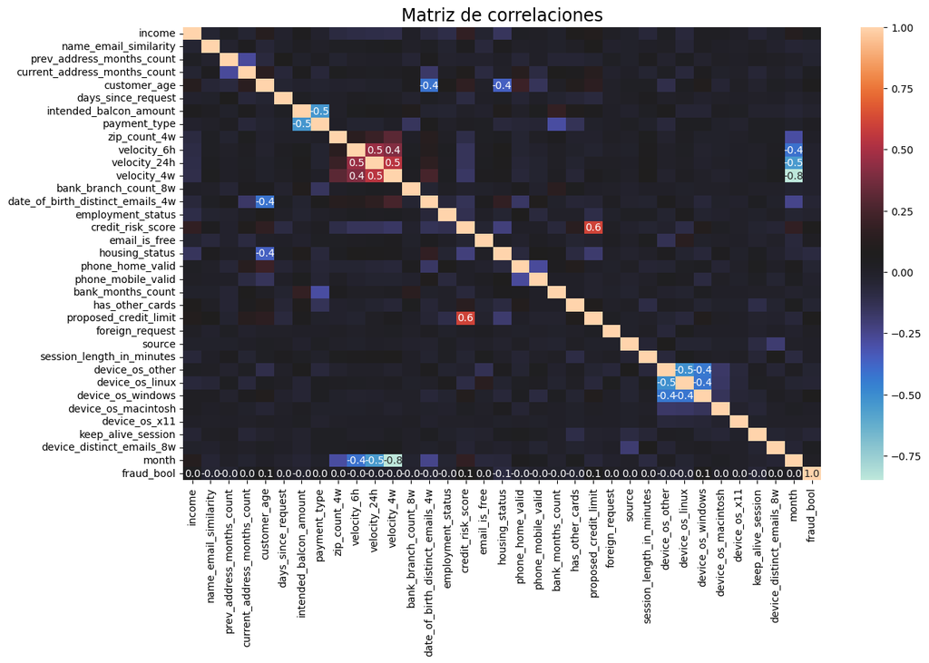

```python
fig,ax = plt.subplots(figsize=(14,8))
sns.heatmap(corr, annot=True, fmt='.1f', cmap='icefire', ax=ax)
for t in ax.texts:
    if ((float(t.get_text())>=0.4) | (float(t.get_text())<=-0.4)) & (float(t.get_text())<1) :
        t.set_text(t.get_text()) # solo quiero que muestre las anotaciones para correlaciones mayores a 0.4, para identificarlos. El resto no me es muy relevante
    elif t in ax.texts[-len(corr.iloc[0]):len(list(ax.texts))]:
        t.set_text(t.get_text()) # además me interesa mostrar todas las correlaciones con mi variable objetivo, en la última fila
    else:
        t.set_text("")
plt.title('Matriz de correlaciones', fontdict={'size':'17'})
plt.show()
```

```python
# Reviso más en detalle las correlaciones con la variable target
corr.loc['fraud_bool'].sort_values(ascending=False)
```

```
fraud_bool                          1.000000
device_os_windows                   0.078716
credit_risk_score                   0.070366
proposed_credit_limit               0.068775
customer_age                        0.061949
income                              0.045500
device_distinct_emails_8w           0.036670
current_address_months_count        0.033850
payment_type                        0.027801
email_is_free                       0.027780
foreign_request                     0.017500
month                               0.012805
session_length_in_minutes           0.009447
device_os_macintosh                 0.006136
zip_count_4w                        0.004552
source                              0.003894
days_since_request                  0.000857
device_os_x11                       0.000335
bank_months_count                  -0.004121
velocity_24h                       -0.011346
velocity_4w                        -0.011712
bank_branch_count_8w               -0.012250
phone_mobile_valid                 -0.012298
velocity_6h                        -0.016439
employment_status                  -0.021768
intended_balcon_amount             -0.024537
prev_address_months_count          -0.025605
phone_home_valid                   -0.035288
has_other_cards                    -0.035710
device_os_other                    -0.036259
name_email_similarity              -0.037349
device_os_linux                    -0.040076
date_of_birth_distinct_emails_4w   -0.043620
keep_alive_session                 -0.049250
housing_status                     -0.078414
Name: fraud_bool, dtype: float64
```

Las correlaciones se mantienen muy similares a las ya vistas, se mantienen las principales ya comentadas.

Además las correlaciones con la variable objetivo también se mantienen en el orden de lo que ya se comentó con anterioridad, destacando solo algunas como el score de riesgo crediticio, la edad, el housing status y como nueva destacada: si el usuario posee windows como sistema operativo.

### Separación X e y

Vuelvo a separar en X e y, por un lado para realizar el escalado por si lo necesito en los modelos, y por el otro para que ya queden los datos ordenados para poder ingresarlos directamente a los modelos en la siguiente práctica:

```python
y_train = df_fraud_train_t['fraud_bool']
X_train = df_fraud_train_t.drop('fraud_bool', axis=1)
y_test = df_fraud_test_t['fraud_bool']
X_test = df_fraud_test_t.drop('fraud_bool', axis=1)

X_train.shape,y_train.shape,y_test.shape,X_test.shape
```

```
((700000, 34), (700000,), (300000,), (300000, 34))
```

```python
pd.concat([X_train,y_train], axis=1).to_csv('../data/processed/df_fraud_train_processed.csv') # luego separaré nuevamente en X e y a la hora de modelar.
pd.concat([X_test,y_test], axis=1).to_csv('../data/processed/df_fraud_test_processed.csv') # lo mismo aplica para el test, se separará luego para no guardar dos csv separados.
```

## Escalado de variables

```python
scaler = StandardScaler()
model_scaled = scaler.fit(X_train)
X_train_scaled = pd.DataFrame(scaler.transform(X_train), columns=X_train.columns, index=X_train.index)
X_test_scaled = pd.DataFrame(scaler.transform(X_test), columns=X_test.columns, index=X_test.index)
```

```python
X_train_scaled.describe()
```

|  | income | name_email_similarity | prev_address_months_count | current_address_months_count | customer_age | days_since_request | intended_balcon_amount | payment_type | zip_count_4w | velocity_6h | velocity_24h | velocity_4w | bank_branch_count_8w | date_of_birth_distinct_emails_4w | employment_status | credit_risk_score | email_is_free | housing_status | phone_home_valid | phone_mobile_valid | bank_months_count | has_other_cards | proposed_credit_limit | foreign_request | source | session_length_in_minutes | device_os_other | device_os_linux | device_os_windows | … |
| --- | --- | --- | --- | --- | --- | --- | --- | --- | --- | --- | --- | --- | --- | --- | --- | --- | --- | --- | --- | --- | --- | --- | --- | --- | --- | --- | --- | --- | --- | --- |
| count | 7.000000e+05 | 7.000000e+05 | 7.000000e+05 | 7.000000e+05 | 7.000000e+05 | 7.000000e+05 | 7.000000e+05 | 7.000000e+05 | 7.000000e+05 | 7.000000e+05 | 7.000000e+05 | 7.000000e+05 | 7.000000e+05 | 7.000000e+05 | 7.000000e+05 | 7.000000e+05 | 7.000000e+05 | 7.000000e+05 | 7.000000e+05 | 7.000000e+05 | 7.000000e+05 | 7.000000e+05 | 7.000000e+05 | 7.000000e+05 | 7.000000e+05 | 7.000000e+05 | 7.000000e+05 | 7.000000e+05 | 7.000000e+05 | … |
| mean | -3.897225e-16 | 5.638461e-16 | -1.652519e-17 | 2.080875e-17 | -1.728040e-16 | 5.469149e-17 | 8.285943e-17 | 1.203456e-16 | 1.088348e-16 | -3.161966e-16 | 3.927576e-16 | -2.773497e-15 | -2.283887e-18 | 4.468299e-17 | -1.374596e-16 | 6.347431e-17 | 9.290854e-17 | 4.191187e-17 | -4.420591e-17 | -4.445967e-17 | -5.765547e-17 | 4.141449e-17 | 3.095936e-17 | -5.982262e-17 | -3.573015e-17 | -2.235672e-16 | 3.367973e-17 | -2.208773e-17 | -3.201503e-17 | … |
| std | 1.000001e+00 | 1.000001e+00 | 1.000001e+00 | 1.000001e+00 | 1.000001e+00 | 1.000001e+00 | 1.000001e+00 | 1.000001e+00 | 1.000001e+00 | 1.000001e+00 | 1.000001e+00 | 1.000001e+00 | 1.000001e+00 | 1.000001e+00 | 1.000001e+00 | 1.000001e+00 | 1.000001e+00 | 1.000001e+00 | 1.000001e+00 | 1.000001e+00 | 1.000001e+00 | 1.000001e+00 | 1.000001e+00 | 1.000001e+00 | 1.000001e+00 | 1.000001e+00 | 1.000001e+00 | 1.000001e+00 | 1.000001e+00 | … |
| min | -1.594075e+00 | -1.707730e+00 | -4.023849e-01 | -9.909203e-01 | -1.969345e+00 | -1.906738e-01 | -1.195904e+00 | -1.273961e+00 | -1.563271e+00 | -1.940562e+00 | -2.347267e+00 | -2.208800e+00 | -4.010217e-01 | -1.888629e+00 | -4.735604e-01 | -4.323292e+00 | -1.061572e+00 | -1.395809e+00 | -8.463876e-01 | -2.837068e+00 | -9.777920e-01 | -5.357603e-01 | -6.681005e-01 | -1.610502e-01 | -8.410693e-02 | -1.062227e+00 | -7.221594e-01 | -7.058631e-01 | -5.981019e-01 | … |
| 25% | -9.052048e-01 | -9.291921e-01 | -4.023849e-01 | -7.646969e-01 | -1.138096e+00 | -1.893374e-01 | -4.868491e-01 | -1.273961e+00 | -6.741084e-01 | -7.412049e-01 | -7.952635e-01 | -6.399373e-01 | -3.988445e-01 | -6.961885e-01 | -4.735604e-01 | -6.895696e-01 | -1.061572e+00 | -6.075737e-01 | -8.463876e-01 | 3.524766e-01 | -9.777920e-01 | -5.357603e-01 | -6.475783e-01 | -1.610502e-01 | -8.410693e-02 | -5.520358e-01 | -7.221594e-01 | -7.058631e-01 | -5.981019e-01 | … |
| 50% | 1.281003e-01 | -5.390576e-03 | -4.023849e-01 | -3.914283e-01 | -3.068482e-01 | -1.878494e-01 | -4.695195e-01 | -2.401296e-01 | -3.080996e-01 | -1.144208e-01 | -1.243392e-02 | 6.164042e-02 | -3.814267e-01 | -9.996825e-02 | -4.735604e-01 | -1.294306e-01 | 9.419991e-01 | 1.806612e-01 | -8.463876e-01 | 3.524766e-01 | -4.826397e-01 | -5.357603e-01 | -6.475783e-01 | -1.610502e-01 | -8.410693e-02 | -3.026301e-01 | -7.221594e-01 | -7.058631e-01 | -5.981019e-01 | … |
| 75% | 8.169704e-01 | 9.058125e-01 | -1.077248e-01 | 4.908430e-01 | 5.244001e-01 | -1.857768e-01 | -1.745057e-01 | 7.937023e-01 | 3.692157e-01 | 6.715990e-01 | 6.643998e-01 | 6.867697e-01 | -3.465910e-01 | 6.949921e-01 | 3.078629e-01 | 6.748716e-01 | 9.419991e-01 | 1.806612e-01 | 1.181492e+00 | 3.524766e-01 | 1.167868e+00 | -5.357603e-01 | -3.191284e-02 | -1.610502e-01 | -8.410693e-02 | 1.636876e-01 | 1.384736e+00 | 1.416705e+00 | 1.671956e+00 | … |
| max | 1.161405e+00 | 1.750902e+00 | 8.301420e+00 | 3.861572e+00 | 4.680641e+00 | 1.406055e+01 | 5.153128e+00 | 2.861366e+00 | 5.099482e+00 | 3.672074e+00 | 3.200819e+00 | 2.318200e+00 | 4.791673e+00 | 5.862234e+00 | 4.214979e+00 | 3.705367e+00 | 9.419991e-01 | 3.333601e+00 | 1.181492e+00 | 3.524766e-01 | 1.745546e+00 | 1.866506e+00 | 3.251636e+00 | 6.209245e+00 | 1.188963e+01 | 9.729333e+00 | 1.384736e+00 | 1.416705e+00 | 1.671956e+00 | … |

# Conclusión del EDA

Una vez concluído el EDA, en donde se analizaron y preprocesaron los componentes del DataSet de este proyecto, podemos decir que nuestros datos se encuentran en condiciones de ser procesados por los modelos que elijamos.

En este análisis hemos logrado:

- Conocer el significado y los valores de cada una de las variables
- Saber cuántos valores nulos, missings y outliers contiene nuestro dataset, para luego haber decidido cual sería su tratamiento.
- Comprender no solo el tipo de dato que contienen las variables analizadas, sino también su naturaleza y características, tanto para el análisis gráfico y descriptivo, como el de su futuro uso en nuestros modelos predictivos
- Entender que tratamos con un dataset desbalanceado, algo que resulta natural por la naturaleza del problema que abordamos, en donde los casos de fraude son absolutamente minoritarios en relación a los casos de no fraude en las aplicaciones de cuentas bancarias.
- Separar de manera estratificada al dataset en subsets de train y de test
- Realizar un análisis gráfico exhaustivo de todas las variables del dataset, destacando los principales detalles a tener en cuenta sobre ellas y sobre su relación con la variable objetivo.
- Comprender las corelaciones entre las variables, tanto numéricas como categóricas
- Encodificar las variables categóricas, convirtiendo sus valores en numéricos para poder procesarlas con éxito en los modelos que elijamos
- Realizar un escalado de todas las variables ya transformadas y preprocesadas por si necesitamos usarlo a la hora de aplicar nuestros modelos

Todo esto nos permitió entender que tratamos con un DataSet de muchas variables de varios tipos, con las cuales buscamos explicar y predecir el comportamiento de nuestra variable objetivo, es decir, cuando una aplicación puede ser fraudulenta y cuando no.

Dicho esto, está claro que nos enfrentamos a un problema extremadamente complejo desde el punto de vista de la medición del éxito de nuestros modelos, debido a que el modelo más simple de todos sería decir que NINGUNA transacción es fraudulenta, ya que sólo tendríamos error en el 1,1% de las veces. El objetivo será intentar mejorar esa marca agregándole complegidad a nuestro análisis.

#### Detalles que deberemos tener en cuenta a la hora de ejecutar modelos:

- Sería efectivo y probablemente necesario el realizar un balanceado del modelo, con técnicas de oversampling por ejemplo.
- Hay variables que identificamos como importantes para predecir el fraude, como el credit risk score y el proposed credit limit, la edad, el income, el housing status, entre algunas otras.
- Por otro lado existe la posibilida de que variables como source aporten poco, debido a que gran parte de sus valores son 0, se debería revisar su utilidad y en todo caso evaluar eliminar la variable del análisis si no aporta mucho valor.
- Hay que recordar eliminar una columna de device_os (OHE) si vamos a hacer modelos de regresión por ej., debido a que se podría duplicar información y generar un sesgo en modelos de este tipo.
- Posibilidad de realizar un Mean Encoding en vez de alguno de los ordinal en caso de que el modelo mejore de esta manera.